# Introducing R

Data Carpentry contributors

## Learning Objectives

> - Begin to appreciate the awesomeness of R
> - Begin to understand some of the backbones of R: functions, objects, vectors, matrices

## Introductions

Alistair Walsh, Software Carpentry Teacher from Res Baz, who has dedicated a big chunk of his time to creating today’s workshop

Res Baz - teaching platform, thanks to Scott Ritchie et al for content suggestions

Jo Keeble - beginner R user who is running today’s workshop with the help and guidance of Alistair

First Round of Participants: Swarna Vijayaraj, Man Lyang Kim, Tom Hayman, Thien Tran, Natasha Janz, Shereen Ong, Fansuo Geng (apologies from Ken and Marilou)

In-house helpers: Matt Ritchie and Alex Garnham

*Please note: this is the debut of this workshop so all feedback is much appreciated*

# The Awesome World of R

## What makes R so Awesome?

- *More powerful* than Excel or Prism (e.g. can handle very large datasets)
- Works with raw data, allowing you to *keep track of transformations* and *reduces chance of errors*
- *Saves time* by streamlining standard analyses e.g. ELISA results
- *Improves consistency* of results, by allowing you to easily perform identical analyses on different datasets
- *Increases reproducibility* of results by allowing others to perform same analyses
- *Highly customisable* in terms of e.g. graphics, statistical analysis
- Capable of *generating reports* with R methods and results e.g. Bioinformatics reports
- *FREE*
- *Community-driven tool* that *keeps getting better and better*!!

## Today’s Workshop

- Introduce R Studio
- Show Demo Plot
- Part 1 using R: start typing scripts, and learn about objects, vectors, matrices
- Online Tools for Learning R
- Part 2 using R: import and analyse ‘cytokine’ dataset

## Hello R Studio

R Studio has 4 windows: R Scripts, Console, Environment/History, and Files/Plots

*Show an example of a script that generates a beautiful graph*

Plot a dataset called ‘iris’ that is stored in R.

‘iris’ is a dataset that contains measurements in cm of 4 variables: sepal width and length, and petal length and width) for 50 flowers from each of the 3 species of Iris.

*Explain briefly each part of the code as you type*

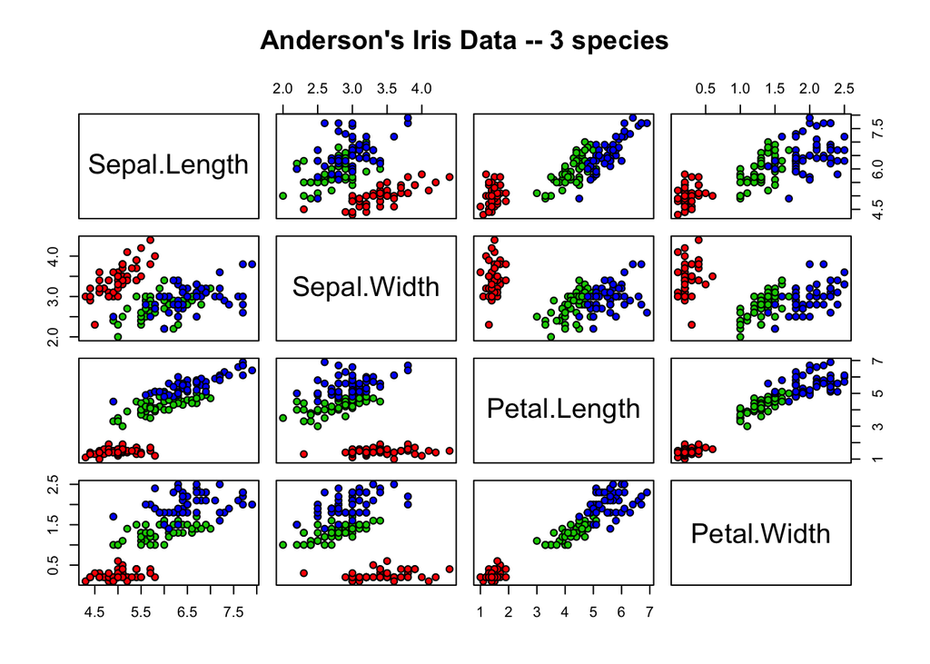

```r
pairs(iris[1:4],
      main = "Anderson's Iris Data -- 3 species",
      pch = 21,
      bg = c("red", "green3", "blue")[unclass(iris$Species)])
```

## Objects in R

R can be used as a calculator:

```r
3 + 5
12/7
sqrt(16)
```

R can assign *values* to *objects* that will be stored:

```r
weight_kg <- 55   # Note: `weight_kg` is different from `Weight_kg`
```

Display values of an object using () or re-type object name:

```r
(weight_kg <- 55)
weight_kg
```

Perform calculations on stored objects, e.g. convert weight_kg to pounds (i.e. multiply by 2.2):

```r
2.2 * weight_kg
```

A variable’s value can be replaced by a new one:

```r
weight_kg <- 57.5
```

Create a new variable based on another stored variable:

```r
weight_lb <- 2.2 * weight_kg
```

## Vectors

A vector is a list of values for one variable. Vector values must be the same type e.g. all numbers.

Create variable ‘x’ with numbers between 2 and 4:

```r
x <- 2:4
```

Create variable ‘y’ with numbers 3, 6, 8 (using ‘c’ to ‘concatenate’/‘combine’):

```r
y <- c(3,6,8)
```

Perform a function on a stored variable:

```r
2 * y
x + y     # add two vectors together
```

Compare vectors:

```r
x < y
x == c(2, 5, 10)
```

A vector can contain characters:

```r
celltype <- c("eosinophils", "basophils", "neutrophils")
```

Extract individual values from vectors using [position]:

```r
celltype[3]
```

Replace values in an existing vector:

```r
celltype[2] <- "dc"
```

Add more values to the end of a vector:

```r
celltype <- c(celltype,"monocytes")
```

Retrieve multiple values from vector:

```r
celltype[3:4]
celltype[c(1,3,5)]
```

Assign names to vector values, then use names to retrieve these values:

```r
y <- c(3,6,8)
names(y) <- c("DCs", "monocytes", "neutrophils")
y["neutrophils"]
```

R has many functions that allow you to inspect the content of a vector:

```r
length(celltype)   # how many elements are there?
class(celltype)    # what is the class (type of element)?
```

The function `str()` gives an overview of the object and the elements it contains:

```r
str(celltype)
```

## Matrices

A matrix is a collection of values arranged in a two-dimensional layout (row x column)

Create a matrix containing numbers 1:15 with 5 rows x 3 columns:

```r
x <- matrix(data = 1:15, nrow = 5, ncol = 3)
x
```

Access values from matrix using [row,column]:

```r
x[2,3]    # row 2, column 3
x[2,]     # all of row 2
x[,3]     # all of column 3
```

Vectors and matrices are some of the many **data structures** that R uses.

Other important ones are lists (`list`), data frames (`data.frame`) and factors (`factor`).

*Morning Tea Break*